# Investigating the Effects of Political Parties on US Inequality

## Matt Arcillo

## Johns Hopkins University

# Introduction

## Income Inequality in the United States

- The United States has the highest inequality among developed nations
- Increasing since 1970s
- Most research regarding inequality focuses on low to middle income earners (Giordono, 2019)
- The middle class is heavily impacted by inequality in the United States (Cortes, 2016)
- Why is inequality so high in United States?

## Income Inequality Globally

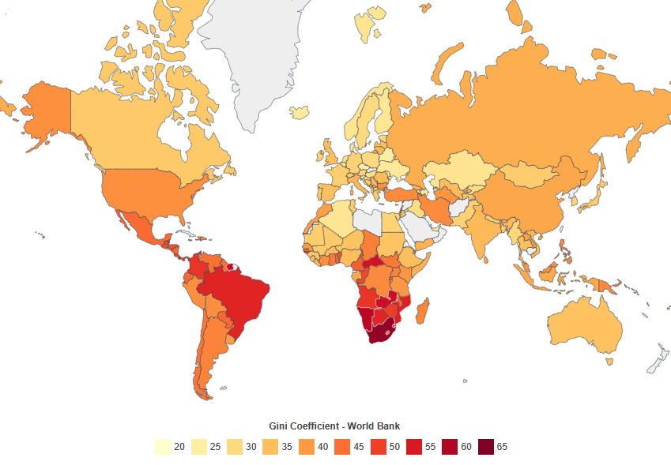

## United States: Leading in Income Inequality Among Developed Nations

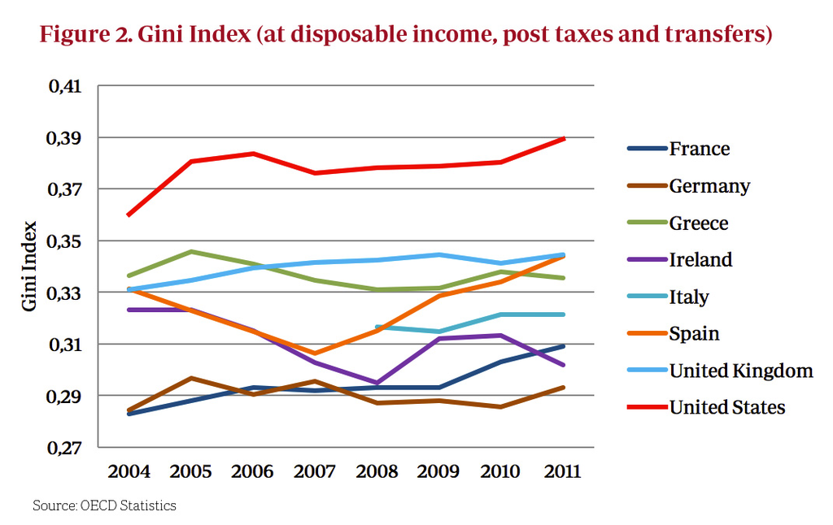

## The Gini Coefficient

- Index of income inequality
- Ranges from 0 (lowest) to 1 (highest)

### Limitations of the Gini Coefficient

- Income vs Wealth
- Income levels: low-wage, middle-class, wealthy
- Household size

## The Two-Party Sytem

- American politics dominated by the Democratic Party and the Republican party
- Congress is in charge of legislation, the President "enforces" new laws or vetoes them
  - Competing interests can slow or halt policies
- Republicans often vote for policies that favour businesses while Democrats often vote for policies that favour labor unions
- Trifectas: when one party controls the House of Representatives, the Senate, and the President

## Goal of Paper

- I will attempt to find a relationship between inequality and political parties
- If a relationship is present, policies could help link political parties and inequality

### Hypothesis

During periods of time when either Congress or the Presidency are Republican, I expect a statistically-significant increase in the Gini coefficient. During periods of trifectas, I expect a statistically-significant change in Gini coefficient.

# Literature Review

# Litmaps

[figure not shown]

## Drivers of Inequality

- Steadily fell during modernization era (Piketty and Saez, 2014)
- Has been rising in United States since 1970s (Piketty and Saez, 2014)
- Technological advancements results in higher inequality among bottom 50% (Danieli, 2022)
- Assymetric effects on wages (Juhn, 1993)
- The replacement of labour with capital (Krusell, 2000)

## Addressing Inequality: Policies

### Minimum wage

- Economists disagree if appropriate when addressing inequality (Autor, 2008)
- Increases in minimum wage can reduce inequality for low-earners (Engelhardt and Purcell, 2021)
- Minimum wage increases may increase overall inequality (Engelhardt and Purcell, 2021)
- 2020 Global Wage Report: Most countries (134) adjust minimum wage every three to five years
- US Federal Minimum Wage: $7.25, set in 2009

## Addressing Inequality: Policies

### Earned Income Tax Credit (EITC)

- Credits for tax refund for low to middle earners

### Alternative Minimum Tax (AMT)

- Prevents wealthy individuals and corporations from using tax deductions to avoid paying taxes
- Has been blamed for worsening inequality for the middle class (Crawford, 2011)

### Improper implementation of policies can lead to worse inequality (Koger, 2021)

## Politics vs Policies

- Democrats often vote for increases to the minimum wage (Bloch, 1980)
- Republicans often vote for policies that keep it stagnant (Bloch, 1980)
- Potential link between political parties and inequality
- During unified Republican state governments, income rises for high-earners (Berkowitz, 2020)
- Opposite occurs when Democrats control the state governemtn (Berkowitz, 2020)

## Pandemics and Recessions

- The COVID-19 pandemic: economically disruptive (Sayed, 2021), (Chen, 2021)
- Global economy goes through cycles of growth and recessions
- Recessions result in a rise in inequality (Heathcote, 2010)
- Inequality that results from recessions are worse for low-income earners (Heathcote, 2020)

### Notable Rises in Inequality

- US Gini rose by .006 in both 2007 and 2008 during the Great Recession
- US Gini rose by .004 and .005 in 2020 and 2021 respectively

# Methodology

## Data

- Data obtained from US Census Bureua
- Using Gini coefficients using equivalence adjusted income
  - To address concerns regarding household size and wealth
- Gini coefficient data will be transformed to annual change in Gini coefficient
- Political party data obtained from senate website

## Analyzing Data

### Four Binary Regressions

1. Relationship between annual Gini coefficient changes and presence of Republican Party unity in Congress.
2. Relationship between annual Gini coefficient changes and presence of Democratic Party unity in Congress.
3. Relationship between annual Gini coefficient changes and the political party of the President.
4. Relationship between annual Gini coefficient changes and presence of trifectas.

# Hypothesis Test

## H<sub>0</sub>

Regressions 1-3: There is no relationship between political parties and annual Gini coefficient change.

Regression 4: There is no relationship between presence of government trifectas and annual Gini coefficient change.

## H<sub>1</sub>

There is a relationship between political parties (1-3)/presence of trifectas (4) and annual Gini coefficient change (|T| > 1.96).

# Results

**Table 1:** Results for Regression 1

| Coefficient Name | Coefficient Value | T-value |
| --- | --- | --- |
| Intercept | 0.0021 | 2.755 |
| Republican Congress | -0.0011 | -0.689 |

**Table 2:** Results for Regression 2

| Coefficient Name | Coefficient Value | T-value |
| --- | --- | --- |
| Intercept | 0.0020 | 2.165 |
| Democratic Congress | -0.0003 | -0.244 |

# Results

**Table 3:** Results for Regression 3

| Coefficient Name | Coefficient Value | T-value |
| --- | --- | --- |
| Intercept | 0.0016 | 1.574 |
| Republican President | 0.0004 | 0.320 |

**Table 4:** Results for Regression 4

| Coefficient Name | Coefficient Value | T-value |
| --- | --- | --- |
| Intercept | 0.0019 | 2.165 |
| Trifecta | -0.0001 | -0.107 |

# Discussion of Findings

## Discussion

- I am choosing to not interpret the coefficients, could lead to innacurate conclusions
- Results do not *disprove* the existence of a relationship
- Possibility that my regression type is not suitable

## Future Research

- Recreate the study with inequality values for varying income levels
  - Possibility of party politics having more of an impact on low or high income households
- Shift the focus towards individual policies and their effects on Gini coefficient
  - Work backwards and find a relationship between political parties and policies
- Test for Republican trifectas vs Democratic trifectas